# Computational Linear Algebra HW3: Complexity, Matrix Norms, Condition Number, and $Ax=b$

Vichearith Meas

*Due Monday, February 21, 2022, 11:59PM. Please submit an html of your completed work on Moodle. If you wish to write things on paper to complement your typed work, you can either submit the hard copy in class on Tuesday or you can upload a picture/scan of your work to Moodle.*

# Part I: Computational Complexity

## Problem 1: Counting arithmetic for $ABv$

One way to predict how long a computation will take is to count the number of “floating-point operations” or “flops” required. A “flop” is one division, multiplication, addition, subtraction, or square root. Here, we are just going to count the multiplications and divisions (which for simplicity we will just call multiplications).

Suppose $A$ and $B$ are $n\times n$ matrices and $v$ is a vector in $\mathbb{R}^n$. Think of $n$ as a large number (much greater than $4$ in particular).

1. One method of computing $y = ABv$ is to first calculate $x=Bv$ and then use that to calculate $y = Ax$. Count the total number of multiplications needed for this method.

   $Bv$ multiplication cost $N^2$ . Multiplication of $ABv$ is also $n^2$. The combined multiplications is $2n^2$.
2. Another method is to compute the matrix $C = AB$ and then form $y = Cv$. Count the total number of multiplications needed for this method.

   In this method, we need to calculated $C$ by multiplying $A$ and $B$. This will take $n^3$ of multiplication since there will be $n$ rows and columns.

   Solving $y= Cv$ will cost the same as part a, $n^2$.

   This makes the total of this b method to be $n^3 + n^2$ .
3. What if we find out that both $A$ and $B$ have low-rank structure like this:
   $$A = u_1y_1^T + u_2y_2^T + u_3y_3^T + u_4y_4^T$$
   $$B = r_1w_1^T + r_2w_2^T + r_3w_3^T + r_4w_4^T$$
   That is, assume we know all of the vectors $u_i, y_i, r_i, w_i$ in these definitions of the $n\times n$ matrices $A$ and $B$. Now, how many multiplications are needed to find $x=Bv$? How many multiplication total to find $ABv$?

   Since $B$ is a $n$x$n$ matrix, then $v$,$r$ and $w$ are $n$x$1$ vector.
   $$Bv = r_1w_1^Tv + r_2w_2^Tv + r_3w_3^Tv + r_4w_4^Tv$$

   So $w^Tv$ costs $n$ multiplication operation for an $1$x$n$ times $n$x$1$. There are four of $w^Tv$ in $Bv$ which makes a total of $4n$.

   $Bv = x$ has a $n$x1 dimension. Similar to $Bv$, $Ax$ will cost $4n$ as $u_iy_i^Tx_i$ cost $n$ multiplication and
   $$Ax = u_1y_1^Tx_1 + u_2y_2^Tx_2 + u_3y_3^Tx_3 + u_4y_4^Tx_4$$

   In total, $ABv$ will cost $8n$.

# Part II: Matrix Norms and Condition Numbers

## Problem 2: The condition number of an orthogonal matrix

A real $n \times n$ matrix $Q$ is *orthonormal* if

$$Q^{T}Q=QQ^T=I;~i.e., Q^{-1}=Q^T.$$

Show that $||Q||_2=||Q^{-1}||_2=1$, and therefore the 2-norm condition number of any orthonormal matrix $Q$ is $\kappa_2(Q)=||Q||_2 ||Q^{-1}||_2=1$.

Notes unrelated to the problem:

- Sometimes you will see these matrices just called *orthogonal matrices*.
- The analagous matrices that contain complex entries ($Q^*Q=QQ^*=I$, where the $~^*$ is a conjugate transpose) are called *unitary*.

$$||Q||_2 = \sqrt{max\{eigen(Q^TQ)\}} = \sqrt{max\{eigen(I)\}} = 1 \\
||Q^{-1}||_2 = ||Q^{T}||_2 = \sqrt{max\{eigen(Q^TQ^{T^T})\}} = \sqrt{max\{eigen(Q^TQ)\}}= \sqrt{max\{eigen(I)\}} = 1 \\
\Downarrow \\
||Q||_2 = ||Q^{-1}||_2 = 1 \\
\Downarrow \\
\kappa_2(Q)=||Q||_2 ||Q^{-1}||_2=(1)(1) = 1$$

## Problem 3: Image of a unit ball under a linear mapping

Here is a `UnitCircleMap` function, which shows the image of the unit ball under a linear mapping $A$ and computes the matrix norm of $A$.

```r
UnitCircleMap <- function(A,p=2) {
  # Compute values of x on the unit circle and compute p-norm of A
  if (p==2) {
    t <- seq(0,2*pi,len=1000)
    x <- cos(t)
    y <- sin(t)
    nn <- norm(A,type="2")
    ni <- as.character(p)
  }
  else if (p==1){
    # Insert some code her
    nn <- norm(A,type="1")
    ni <- as.character(p)
  }
  else if (p=="I"){
    # Insert some code here
    nn <- norm(A,type="I")
    ni <- "Inf"
  }

  # Compute values of Ax
  pts <- A %*% t(cbind(x,y))
  newx <- pts[1,]
  newy <- pts[2,]

  # Assemble into a data frame
  xx <- c(x,newx)
  yy <- c(y,newy)
  type=c(rep("x",length(x)),rep("Ax",length(newx)))
  df <- data.frame(x=xx,y=yy,type=type)

  normSize <- sprintf("||A||_%s = %1.2f",ni,nn)
  M <- max(c(1.01*newx, 1.01*newy, 1.5))

  # Plot
  ggplot(df,aes(x=x,y=y,color=type))+
    geom_point()+
    labs(x="x1",y="x2",color=element_blank())+
    coord_fixed(ratio=1)+
    scale_color_manual(values=c("red","black"))+
    ggtitle(normSize)+
    lims(x=c(-M,M),y=c(-M,M))
}
```

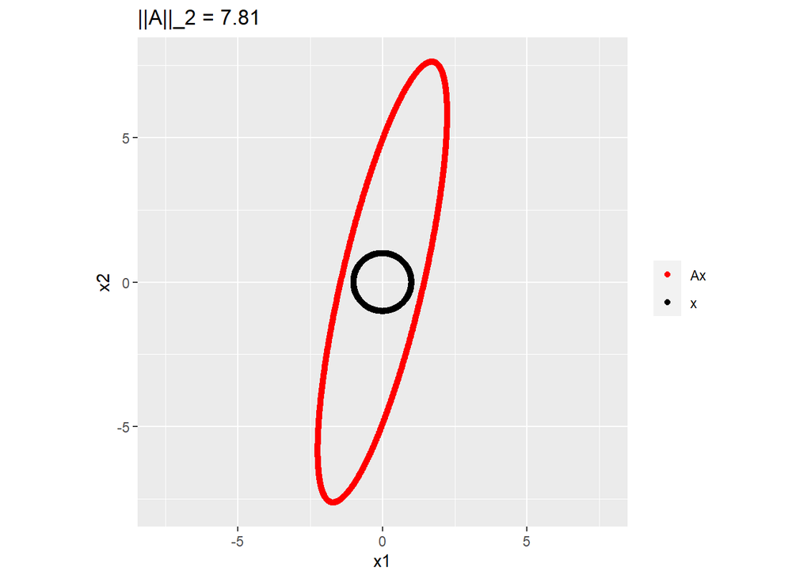

```r
A <- cbind(c(2,3),c(1,7))
UnitCircleMap(A,2)
```

1. My `UnitCircleMap` function currently only works for the $p=2$ norm. Modify it to let the user choose the norm to be 1, 2, or $\infty$ (“I”), by filling in the two missing sections of code. Test your function on the same $A$ matrix from above.

   ```r
   UnitCircleMap <- function(A,p=2) {
     # Compute values of x on the unit circle and compute p-norm of A
     if (p==2) {
       t <- seq(0,2*pi,len=1000)
       x <- cos(t)
       y <- sin(t)
       nn <- norm(A,type="2")
       ni <- as.character(p)
     }
     else if (p==1){
       # Insert some code here
       x = seq(-1,1, len= 1000)
       y = 1 - abs(x)
       x = c(x,x)
       y = c(y,-y)
       nn <- norm(A,type="1")
       ni <- as.character(p)
     }
     else if (p=="I"){
       # Insert some code here
       x = c(rep(1,500), rep(-1,500), seq(-1,1,len=500),seq(-1,1,len=500) )
       y = c(seq(-1,1, len=500),seq(-1,1, len=500),rep(1,500),rep(-1,500) )
       nn <- norm(A,type="I")
       ni <- "Inf"
     }

     # Compute values of Ax
     pts <- A %*% t(cbind(x,y))
     newx <- pts[1,]
     newy <- pts[2,]

     # Assemble into a data frame
     xx <- c(x,newx)
     yy <- c(y,newy)
     type=c(rep("x",length(x)),rep("Ax",length(newx)))
     df <- data.frame(x=xx,y=yy,type=type)

     normSize <- sprintf("||A||_%s = %1.2f",ni,nn)
     M <- max(c(1.01*newx, 1.01*newy, 1.5))

     # Plot
     ggplot(df,aes(x=x,y=y,color=type))+
       geom_point()+
       labs(x="x1",y="x2",color=element_blank())+
       coord_fixed(ratio=1)+
       scale_color_manual(values=c("red","black"))+
       ggtitle(normSize)+
       lims(x=c(-M,M),y=c(-M,M))
   }
   ```

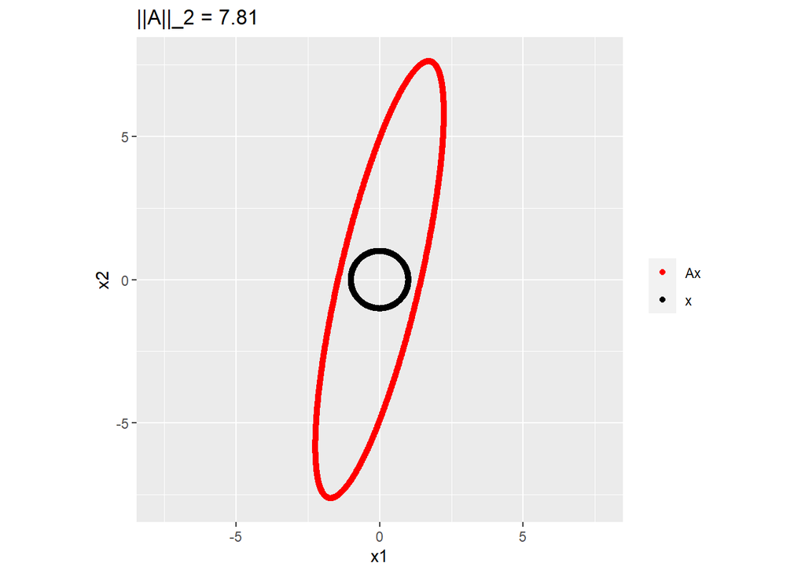

   ```r
   UnitCircleMap(A,2)
   ```

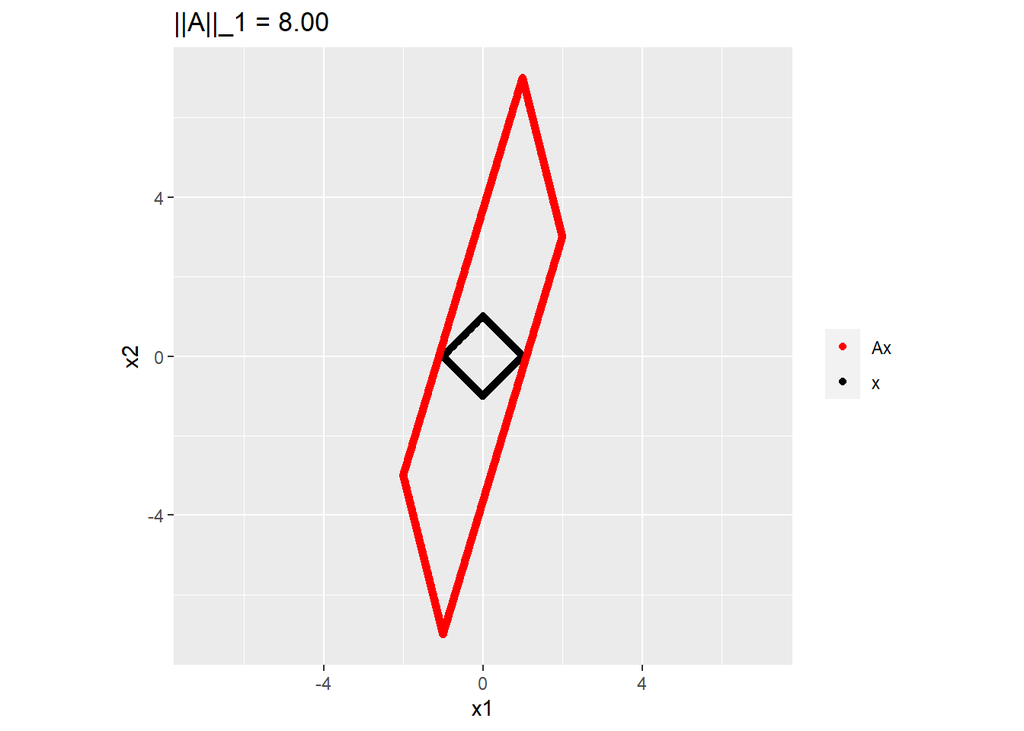

   ```r
   UnitCircleMap(A,1)
   ```

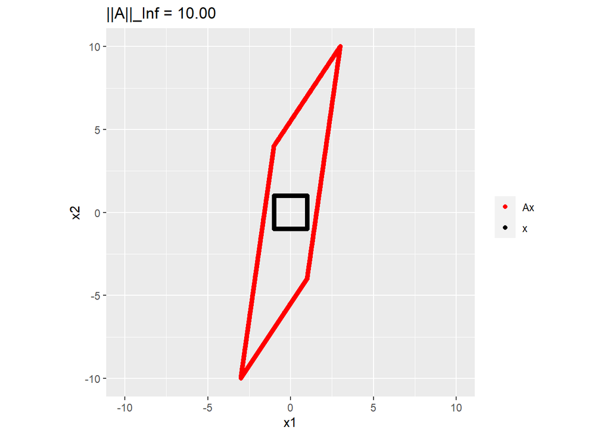

   ```r
   UnitCircleMap(A,"I")
   ```

2. Use your code to determine whether $||Q||_1=||Q||_{\infty}=||Q||_2=1$ for all orthonormal matrices $Q$.

   **Hint**: Try $Q=\begin{pmatrix} \frac{1}{\sqrt{2}} & \frac{-1}{\sqrt{2}} \\ \frac{1}{\sqrt{2}} & \frac{1}{\sqrt{2}} \end{pmatrix}$, which is a rotation matrix that rotates vectors counter-clockwise by $\frac{\pi}{4}$.

   Based on the example below, it seems that the $||Q||_1=||Q||_{\infty}=||Q||_2=1$ does not always true. The $Q$ matrix is a orthonormal matrix but the value of $||Q||_1$, $||Q||_{\infty}$, and $||Q||_2=1$ are different.

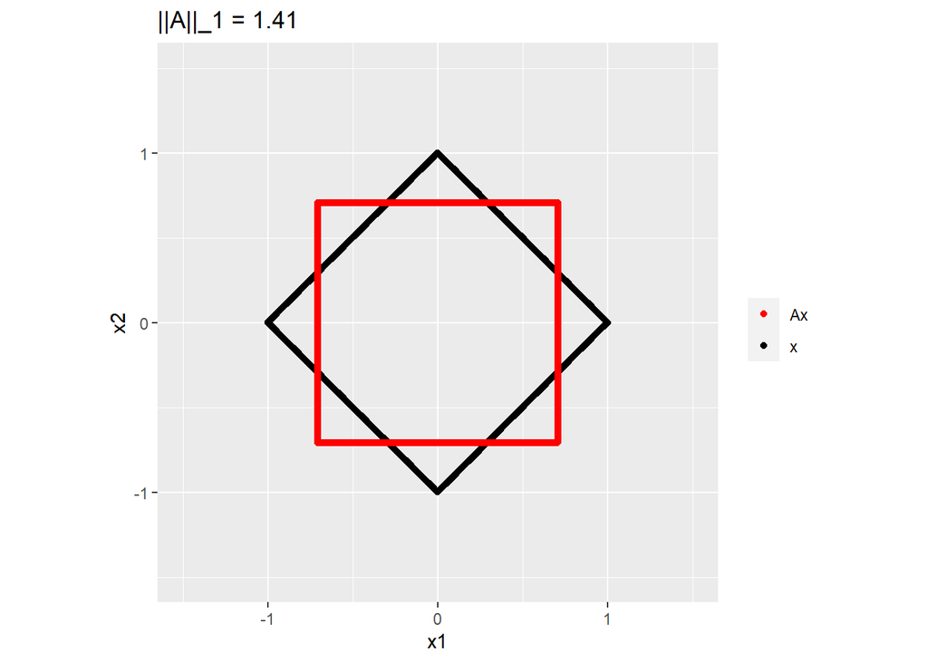

   ```r
   Q = matrix(c(1/sqrt(2), -1/sqrt(2), 1/sqrt(2), 1/sqrt(2) ), byrow=TRUE, nrow=2)
   UnitCircleMap(Q,1)
   ```

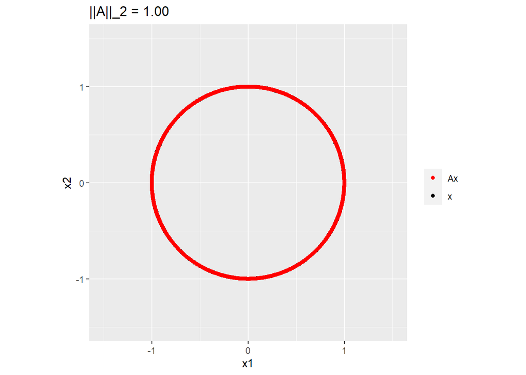

   ```r
   UnitCircleMap(Q,2)
   ```

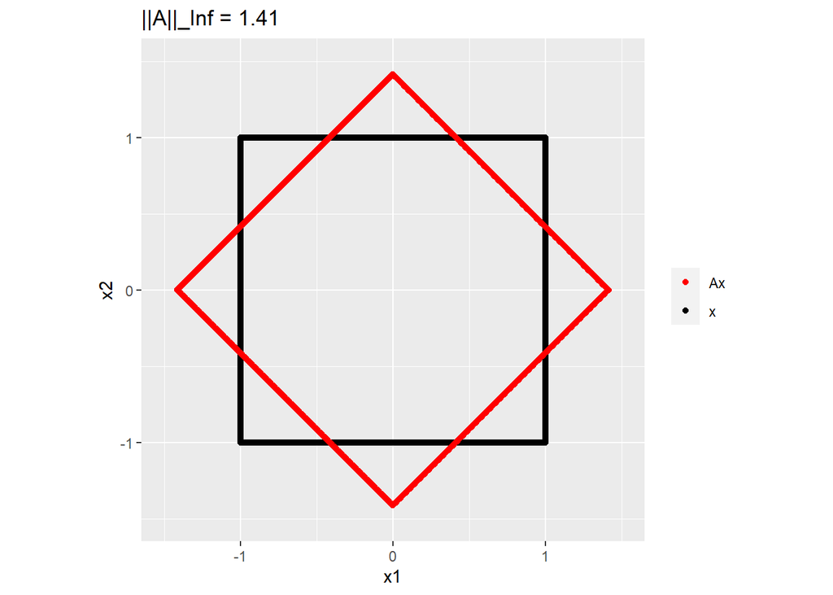

   ```r
   UnitCircleMap(Q,"I")
   ```

   ```r
   Q%*%t(Q)
   ```

   ```
   ##      [,1] [,2]
   ## [1,]    1    0
   ## [2,]    0    1
   ```

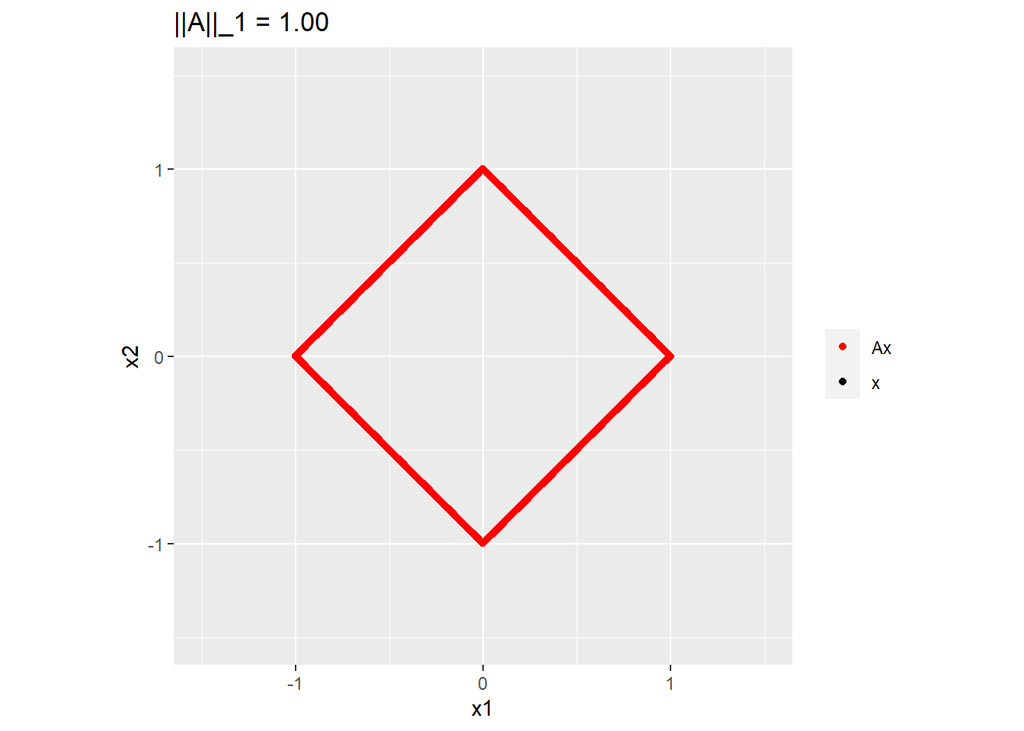

   ```r
   F = matrix(c(1*cos(pi), -2*sin(pi),
                2*sin(pi),1*cos(pi)), byrow=TRUE, nrow=2)
   UnitCircleMap(F,1)
   ```

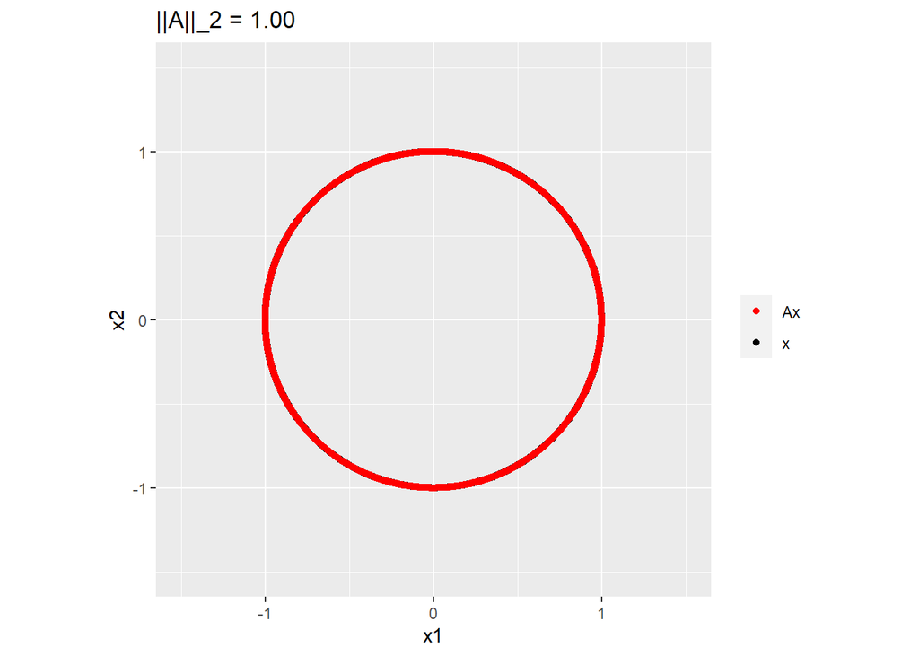

   ```r
   UnitCircleMap(F,2)
   ```

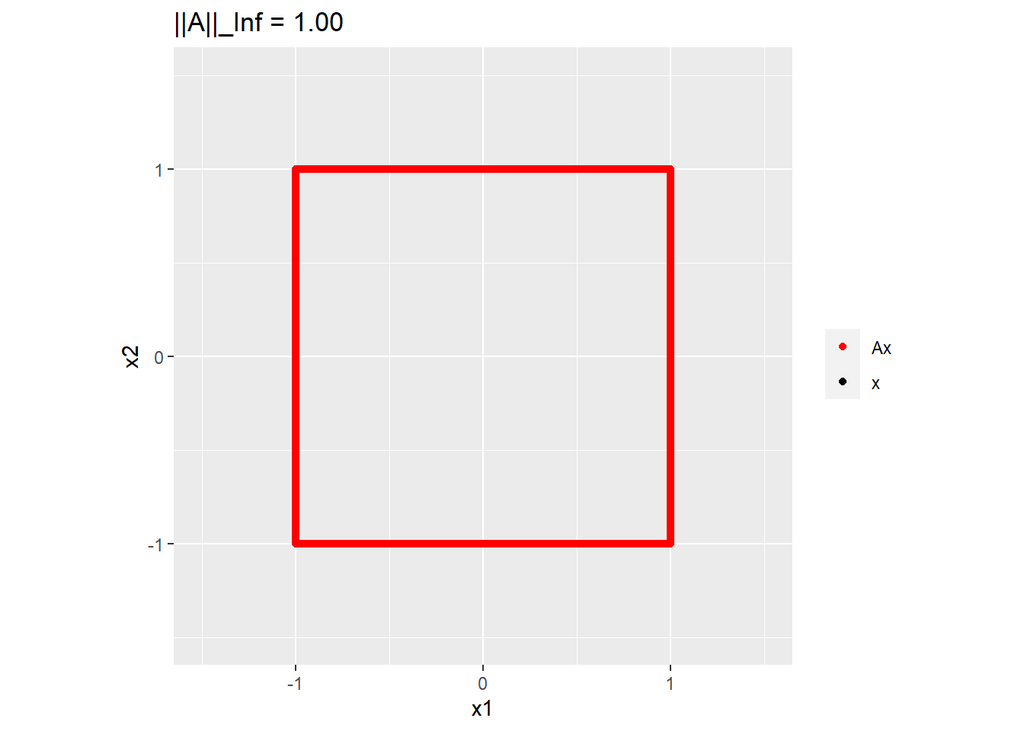

   ```r
   UnitCircleMap(F,"I")
   ```

   ```r
   F%*%t(F)
   ```

   ```
   ##      [,1] [,2]
   ## [1,]    1    0
   ## [2,]    0    1
   ```

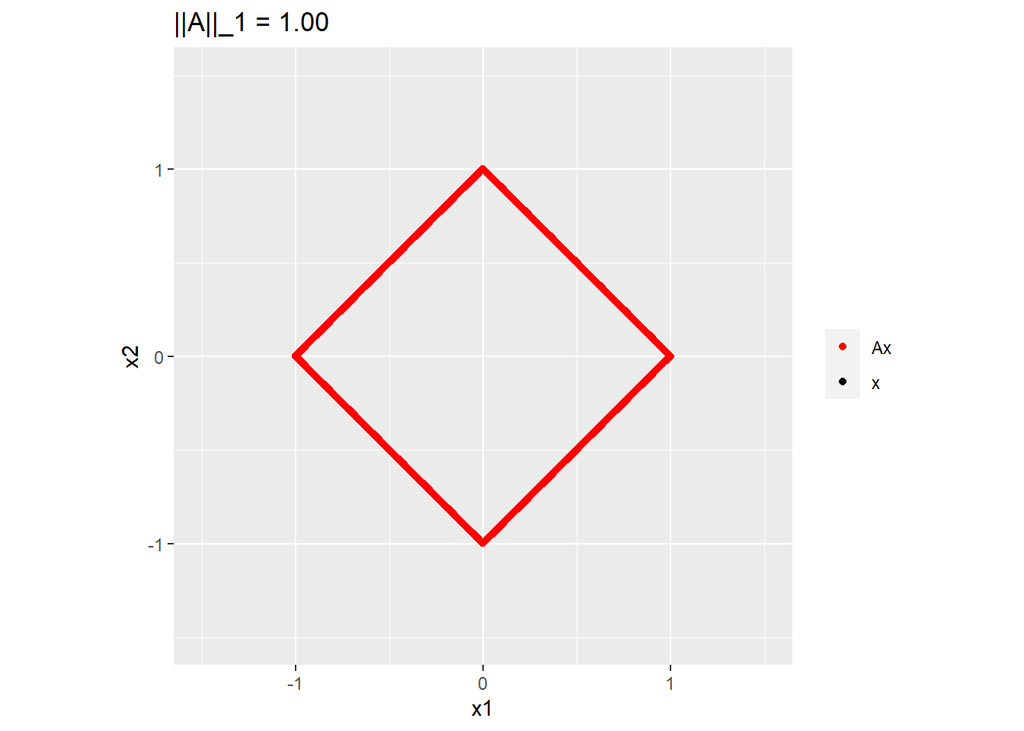

   ```r
   R = matrix(c(1,0,0,-1), byrow=TRUE, nrow=2) # (reflection across x-axis)
   UnitCircleMap(R,1)
   ```

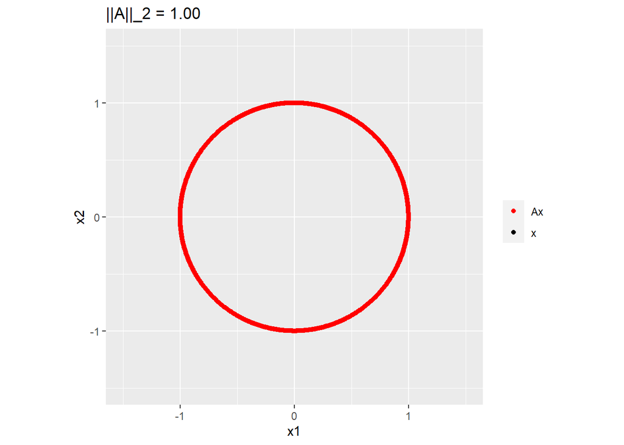

   ```r
   UnitCircleMap(R,2)
   ```

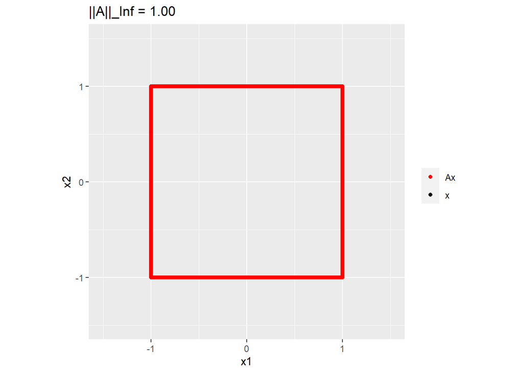

   ```r
   UnitCircleMap(R,"I")
   ```

# Part II: $Ax=b$

## Problem 4: Applications of linear systems

Write one paragraph describing a “real world” application you find interesting where it is important to solve large systems of linear equations.

A interesting life application of system of linear equation for me is about solving traffic flow that was first mentioned to me in linear algebra class. It was a common yet powerful example to shows the power of linear algebra in solving complex and interconnected problem. When I was asked to solve the problem, I could think of a way to approach the issue. When the problem get translated into system of equation, everything becomes easier to solve. That is powerful.

This example of the traffic flow problem is just a variation many networking problems that can be solved using large systems of linear equations. These networking problems could be current flow on a circuit board, liquid flow in a pipe system, irrigation management, etc.

## Problem 5: Proof of key step in A=LU

In class, we showed how to construct a sequence of unit lower-triangular matrices $\{L_{k}\}_{k=1,2,\ldots,n-1}$ of the form

$$L_{k}=\begin{pmatrix} 1 & & & & & \\
& \ddots & & & & \\
& & 1 & & & \\
& & -\ell_{k+1,k} & 1 & & \\
& & \ddots & & \ddots & \\
& & -\ell_{n,k} & & & 1
\end{pmatrix}~, \hbox{ where } \ell_{j,k}=\frac{A_{j,k}}{A_{k,k}},~\hbox{ for } k\leq j \leq n,$$

such that

$$L_{n-1} L_{n-2} \ldots L_{2} L_{1} A = U,$$

with $U$ being an upper-triangular matrix. We now want to show in two steps that

$$L:= L_{1}^{-1} L_{2}^{-1} \ldots L_{n-2}^{-1} L_{n-1}^{-1}$$

is a unit lower-triangular matrix.

1. Show that

   $$L_{k}^{-1} = \begin{pmatrix} 1 & & & & & \\
   & \ddots & & & & \\
   & & 1 & & & \\
   & & \ell_{k+1,k} & 1 & & \\
   & & \ddots & & \ddots & \\
   & & \ell_{n,k} & & & 1
   \end{pmatrix}.$$

   **Hint**: Start by showing that $L_k=I-\ell_k e_k^{T}$, where $e_k$ is an $n \times 1$ vector with a 1 in the $k^{th}$ entry, and zeros elsewhere, and

   $$\ell_k = \begin{pmatrix} 0 \\ \vdots \\ 0 \\ \ell_{k+1,k} \\ \vdots \\ \ell_{n,k} \end{pmatrix}.$$

   $$e_k = \begin{pmatrix} 0 \\ \vdots \\ e_{k} = 1 \ \\ \vdots \\ 0 \\ \end{pmatrix} \Rightarrow \ell_k e_k^T = \begin{pmatrix} 0 \\\vdots \\ 0 \\ \ell_{k+1,k} \\\vdots \\ \ell_{n,k} \end{pmatrix}\begin{pmatrix} 0 & \cdots & 1 &\cdots 0\end{pmatrix} =
   \begin{pmatrix}
   0 & & & & & \\
   & \ddots & & & & \\
   & & 0 & & & \\
   & & \ell_{k+1,k} & 0 & & \\
   & & \vdots & & \ddots & \\
   & & \ell_{n,k} & & & 0
   \end{pmatrix}$$

   $$(I + \ell_k e_k^T)(I - \ell_k e_k^T) = I^2 - \ell_ke_k^T\ell_k e_k^T$$

   However, $I -\ell_k e_k^T = L_k$.

   $$(I + \ell_k e_k^T)(I - \ell_k e_k^T) = (I + \ell_k e_k^T)L_k = I \\
   \Downarrow \\
   I + \ell_k e_k^T = L_k^{-1} \\
   \Downarrow \\
   L_k^{-1} = \begin{pmatrix}
   1 & & & & & \\
   & \ddots & & & & \\
   & & 1 & & & \\
   & & \ell_{k+1,k} & 1 & & \\
   & & \vdots & & \ddots & \\
   & & \ell_{n,k} & & & 1
   \end{pmatrix} \\$$
2. Now show that

   $$L:= L_{1}^{-1} L_{2}^{-1} \ldots L_{n-2}^{-1} L_{n-1}^{-1} = \begin{pmatrix} 1 & & & & \\
   \ell_{21} & 1 & & & \\
   \ell_{31} & \ell_{32} & 1 & & \\
   \vdots & \vdots & \ddots & \ddots & \\
   \ell_{n1} & \ell_{n2} & \cdots & \ell_{n,n-1} & 1 \\
   \end{pmatrix}$$

   $$\begin{align*}
   L_{1}^{-1} L_{2}^{-1} \ldots L_{n-2}^{-1} L_{n-1}^{-1}
   =& (I + \ell_1 e_1^T)(I + \ell_2 e_2^T)\ldots (I + \ell_{n-2} e_{n-2}^T)(I + \ell_{n-1} e_{n-1}^T) \\
   =& (I^2 + I\ell_2 e_2^T + \ell_1 e_1^TI + \ell_1 e_1^T\ell_2 e_2^T )\ldots (I^2 + I\ell_{n-1} e_{n-1}^T + \ell_{n-2} e_{n-2}^TI + \ell_{n-2} e_{n-2}^T\ell_{n-1} e_{n-1}^T ) \\
   & \text{since we show that } e_k^T\ell_{k} = 0 \text{ so is the } e_k^T\ell_{k+1} = 0\\
   =& (I + \ell_2 e_2^T + \ell_1 e_1^T + \ell_1 e_1^T\ell_2 e_2^T )\ldots (I + \ell_{n-1} e_{n-1}^T + \ell_{n-2} e_{n-2}^T + \ell_{n-2} e_{n-2}^T\ell_{n-1} e_{n-1}^T ) \\
   =& (I + \ell_2 e_2^T + \ell_1 e_1^T )(I + \ell_4 e_4^T + \ell_3 e_3^T )\ldots (I + \ell_{n-3} e_{n-3}^T + \ell_{n-4} e_{n-4}^T)(I + \ell_{n-1} e_{n-1}^T + \ell_{n-2} e_{n-2}^T)\\
   =& (I^2 + \ell_4 e_4^T + \ell_3 e_3^T + \ell_2 e_2^T + \ell_2 e_2^T\ell_4 e_4^T + \ell_2 e_2^T \ell_3 e_3^T + \ell_1 e_1^T + \ell_1 e_1^T\ell_4 e_4^T + \ell_1 e_1^T\ell_3 e_3^T )\ldots (I^2 + \ldots + \ell_{n-4} e_{n-4}^T\ell_{n-2} e_{n-2}^T)\\
   =& (I + \ell_4 e_4^T + \ell_3 e_3^T + \ell_2 e_2^T + \ell_1 e_1^T)\ldots (I + \ell_{n-4} e_{n-4}^T + \ell_{n-3} e_{n-3}^T + \ell_{n-2} e_{n-2}^T + \ell_{n-1} e_{n-1}^T )\\
   &\ldots \\
   =& (I + \ell_1 e_1^T + \ell_2 e_2^T + \ldots + \ell_{n-4} e_{n-4}^T + \ell_{n-3} e_{n-3}^T + \ell_{n-2} e_{n-2}^T + \ell_{n-1} e_{n-1}^T )\\
   \end{align*}$$

   Each $\ell_k e_k^T$ in $I + \ell_1 e_1^T + \ell_2 e_2^T + \ldots + \ell_{n-4} e_{n-4}^T + \ell_{n-3} e_{n-3}^T + \ell_{n-2} e_{n-2}^T + \ell_{n-1} e_{n-1}^T$ is a zero matrix with entry in column $k$th from row $(k+1)$ to $n$; therefore, $L_{1}^{-1} L_{2}^{-1} \ldots L_{n-2}^{-1} L_{n-1}^{-1}$ is a combination of an identity matrix $I$ and columns under the diagonal line from 1 to $n-1$.

## Problem 6: Heat transfer application

*This problem is from Section 2.5, page 131 of Linear Algebra and Its Applications, by David Lay, the textbook many of you used for MATH 236.*

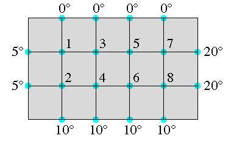

An important concern in the study of heat transfer is to determine the steady-state temperature distribution of a thin plate when the temperature around the boundary is known. Assume the plate shown in the figure above represents a cross section of a metal beam, with negligible heat flow in the direction perpendicular to the plate. Let the variables $x_1, x_2, \ldots, x_8$ denote the temperatures at nodes 1 through 8 in the picture. In steady state, the temperature at a node is approximately equal to the average of the four nearest nodes (to the left, above, right, below).

1. The solution to the approximate steady-state heat flow problem for this plate can be written as a system of linear equations $Ax=b$, where $x=[x_1, x_2, \ldots, x_8]$ is the vector of temperatures at nodes 1 through 8. Find the $8 \times 8$ matrix $A$ and the vector $b$. Hint: $A$ should be a banded matrix with many zeros in the top right and bottom left parts of $A$.

   The system of equation represent the relationship between nodes:

   $$\begin{cases}
   4x_1 = 0 + 5 + x_2 + x_3\\
   4x_2 = 10 + 5 + x_1 + x_4\\
   4x_3 = 0 + x_5 + x_1 + x_4\\
   4x_4 = 10 + x_3 + x_2 + x_6\\
   4x_5 = 0 + x_3 + x_7 + x_6\\
   4x_6 = 10 + x_4 + x_5 + x_8\\
   4x_7 = 0 + 20 + x_5 + x_8\\
   4x_8 = 10 + 20 + x_6 + x_7
   \end{cases}$$

   $$A = \begin{pmatrix}
   -4 & 1 & 1 & 0 & 0 & 0 & 0 & 0 \\
   1 &-4 & 0 & 1 & 0 & 0 & 0 & 0 \\
   1 & 0 &-4 & 1 & 1 & 0 & 0 & 0 \\
   0 & 1 & 1 &-4 & 0 & 1 & 0 & 0 \\
   0 & 0 & 1 & 0 &-4 & 1 & 1 & 0 \\
   0 & 0 & 0 & 1 & 1 &-4 & 0 & 1 \\
   0 & 0 & 0 & 0 & 1 & 0 &-4 & 1 \\
   0 & 0 & 0 & 0 & 0 & 1 & 1 &-4
   \end{pmatrix}$$

   The lower matrix $L$ and upper matrix $U$ are banded matrices with many zeros in the top right and bottom left parts similar to the original matrix $A$.

   ```r
   myUL = function(A){
   if (nrow(A) != ncol(A)){
     return('No Square Matrix')
   }

   n = nrow(A)
   U = A
   L = spMatrix(n,n, i= 1:n, j=1:n, x=rep(1,n))

   for(k in 1:(n-1)){   # RUN N-1 TIME
     if( U[k,k] == 0){
       stop('Zero Pivot found!')
     }

     for(j in (k+1):n){  # PROCESS ROW: FROM PIVOT TO THE END
       L[j,k] = U[j,k]/U[k,k]        # FOR EACH ROW IN COL, ENTRY/PIVOT
       U[j,k:n] = U[j,k:n] - L[j,k]*U[k,k:n]
     }
   }

   return(list(L= L, U=U))
   }



   P6 = spMatrix(8,8,
                  i=c(1:8,seq(2, 8, 2),  seq(1, 8, 2), 3:8 , 1:6),
                  j=c(1:8, seq(1, 8, 2), seq(2, 8, 2), 1:6 , 3:8),
                  x=c(rep(-4,8), rep(1,4), rep(1,4), rep(1,6), rep(1,6)))

   P6b = matrix(c(-5 ,-10,0 ,-10, 0,-10,-20,-30 ), nrow = 8, ncol = 1)
   P6A = myUL(P6)
   P6A
   ```

   ```
   ## $L
   ## 8 x 8 sparse Matrix of class "dgTMatrix"
   ##
   ## [1,]  1.00  .           .          .           .          .           .
   ## [2,] -0.25  1.00000000  .          .           .          .           .
   ## [3,] -0.25 -0.06666667  1.0000000  .           .          .           .
   ## [4,]  .    -0.26666667 -0.2857143  1.00000000  .          .           .
   ## [5,]  .     .          -0.2678571 -0.08333333  1.0000000  .           .
   ## [6,]  .     .           .         -0.29166667 -0.2921348  1.00000000  .
   ## [7,]  .     .           .          .          -0.2696629 -0.08612836  1.0000000
   ## [8,]  .     .           .          .           .         -0.29482402 -0.2931381
   ##
   ## [1,] .
   ## [2,] .
   ## [3,] .
   ```

   [output cut: 17 more lines]

3. Once you have an LU factorization for a matrix $A$, you need to do the two-step procedure to complete the back substitution to solve $Ax=b$. Here is code for that:

   ```r
   mySolve<-function(L,U,b,tol=1e-10){

     n <- nrow(L)

     # First solve Ly=b
     y <- rep(0,n)        # pre-allocate a vector y with 0s in it.
     if(abs(L[1,1])<tol) stop('There is a zero on the diagonal of L')
     y[1] <- b[1]/L[1,1]  # Fill in the 1st value of y
     for (j in 2:n ) {
   if(abs(L[j,j])<tol) stop('There is a zero on the diagonal of L')
   y[j] <- (b[j] - L[j,1:(j-1)]%*%y[1:(j-1)])/L[j,j]
     }

     # Then solve Ux=y
     x <- rep(0,n)        # pre-allocate a vector x with 0s in it.
     if(abs(U[n,n])<tol) stop('There is a zero on the diagonal of U')
     x[n] <- y[n]/U[n,n]  # Fill in the nth value of x
     for (j in (n-1):1 ) {
   if(abs(U[j,j])<tol) stop('There is a zero on the diagonal of U')
   x[j] <- (y[j] - U[j,(j+1):n]%*%x[(j+1):n])/U[j,j]
     }
     return(x)
   }
   ```

   Make sure you understand what the code is doing, and then use it to find the steady-state temperatures at nodes 1 through 8.

   ```r
   P6b
   ```

   ```
   ##      [,1]
   ## [1,]   -5
   ## [2,]  -10
   ## [3,]    0
   ## [4,]  -10
   ## [5,]    0
   ## [6,]  -10
   ## [7,]  -20
   ## [8,]  -30
   ```

   ```r
   mySolve(P6A$L, P6A$U, P6b)
   ```

   ```
   ## [1]  3.524171  5.112193  3.984491  6.924600  5.489193  8.601716  9.370566
   ## [8] 11.993070
   ```

4. The temperature on the right-hand side of the plate was measured incorrectly. It is actually 30 degrees. Find the new steady-state temperatures. Hint: you should not do another LU factorization!

   The mismeasurement on the right-hand side of the plate affect node 7 and 8. Just need to update row 7 and 8 in $b$. The system of equation stay the same except vector $b$.

   ```r
   P6b_correct = matrix(c(-5 ,-10,0 ,-10, 0,-10,-30,-40 ), nrow = 8, ncol = 1)
   mySolve(P6A$L, P6A$U, P6b_correct)
   ```

   ```
   ## [1]  3.705989  5.294011  4.529946  7.470054  6.943739 10.056261 13.188748
   ## [8] 15.811252
   ```

5. Use the R function `solve(A)` to compute $A^{-1}$. Note that $A^{-1}$ is a **dense** matrix (without many zeros). When $A$ is large, $L$ and $U$ can be stored in much less space than $A^{-1}$. This fact is another reason for preferring the LU factorization of $A$ to $A^{-1}$ itself.

   ```r
   solve(P6)
   ```

   ```
   ## 8 x 8 sparse Matrix of class "dgCMatrix"
   ##
   ## [1,] -0.295264808 -0.086553374 -0.09450586 -0.05094869 -0.03180993 -0.02273552
   ## [2,] -0.086553374 -0.295264808 -0.05094869 -0.09450586 -0.02273552 -0.03180993
   ## [3,] -0.094505857 -0.050948688 -0.32707474 -0.10928890 -0.10450421 -0.05913216
   ## [4,] -0.050948688 -0.094505857 -0.10928890 -0.32707474 -0.05913216 -0.10450421
   ## [5,] -0.031809932 -0.022735522 -0.10450421 -0.05913216 -0.32707474 -0.10928890
   ## [6,] -0.022735522 -0.031809932 -0.05913216 -0.10450421 -0.10928890 -0.32707474
   ## [7,] -0.009998350 -0.008183468 -0.03180993 -0.02273552 -0.09450586 -0.05094869
   ## [8,] -0.008183468 -0.009998350 -0.02273552 -0.03180993 -0.05094869 -0.09450586
   ##
   ## [1,] -0.009998350 -0.008183468
   ## [2,] -0.008183468 -0.009998350
   ## [3,] -0.031809932 -0.022735522
   ## [4,] -0.022735522 -0.031809932
   ## [5,] -0.094505857 -0.050948688
   ## [6,] -0.050948688 -0.094505857
   ## [7,] -0.295264808 -0.086553374
   ## [8,] -0.086553374 -0.295264808
   ```

## Problem 7: $PA=LU$ example

Solve the following system by finding the $PA=LU$ factorization and then carrying out the two-step back substitution (all by hand):

$$A=\begin{pmatrix}
-1 & 0 & 1 \\
3 & 1 & 1 \\
2 & 0 & 1
\end{pmatrix} \begin{pmatrix} x_1 \\ x_2\\ x_3\end{pmatrix}=\begin{pmatrix} 2 \\ 5 \\ 5 \end{pmatrix}.$$
$$B=\begin{pmatrix}
2 & -1 & -1& -1& -1& -1& -1& 0& 0& 0& 0& 0& 0& 0\\
-1 & 2 & 0 & 0 & 0 &-1 &-1 & 0 & 0 & 0 & 0 & 0 & 0 &-1\\
0 & -1 & 2 &-1 &-1 & 0 & 0 & 0 & 0 & 0 & 0 & 0 & 0 & 0\\
0 & 0 & 0 & 2 &-1 & 0 & 0 &-1 &-1 &-1 & 0 & 0 & 0 & 0\\
0 & 0 & 0 &-1 & 2 & 0 & 0 & 0 & 0 & 0 &-1 &-1 &-1 & 0\\
0 & 0 & 0 & 0 & 0 & 2 &-1 & 0 & 0 & 0 & 0 & 0 & 0 &-1\\
0 & 0 & 0 & 0 & 0 &-1 & 2 & 0 & 0 & 0 & 0 & 0 & 0 &-1\\
0 & 0 & 0 & 0 & 0 & 0 & 0 & 2 & 0 &-1 & 0 & 0 & 0 & 0\\
0 & 0 & 0 & 0 & 0 & 0 & 0 & 0 & 2 &-1 & 0 & 0 & 0 & 0\\
0 & 0 & 0 & 0 & 0 & 0 & 0 & 0 & 0 & 2 & 0 & 0 & 0 & 0\\
0 & 0 & 0 & 0 & 0 & 0 & 0 & 0 & 0 & 0 & 2 & 0 & 0 & 0\\
0 & 0 & 0 & 0 & 0 & 0 & 0 & 0 & 0 & 0 & 0 & 2 & 0 & 0\\
0 & 0 & 0 & 0 & 0 & 0 & 0 & 0 & 0 & 0 & 0 & 0 & 2 & 0\\
0 & 0 & 0 & 0 & 0 & 0 & 0 & 0 & 0 & 0 & 0 & 0 & 0 & 2\\
\end{pmatrix}$$

Factorization

$$A = \begin{pmatrix}
-1 & 0 & 1 \\
3 & 1 & 1 \\
2 & 0 & 1
\end{pmatrix}$$
$$\begin{align*}
P=&\begin{pmatrix}
0 & 1 & 0 \\
0 & 0 & 1 \\
1 & 0 & 0
\end{pmatrix}
&L =&\begin{pmatrix}
1 & 0 & 0 \\
0 & 1 & 0 \\
0 & 0 & 1
\end{pmatrix}
&U=&\begin{pmatrix}
3 & 1 & 1 \\
2 & 0 & 1 \\
-1 & 0 & 1
\end{pmatrix} \\
\hline
P=&\begin{pmatrix}
0 & 1 & 0 \\
0 & 0 & 1 \\
1 & 0 & 0
\end{pmatrix}
&L =&\begin{pmatrix}
1 & 0 & 0 \\
\frac{2}{3} & 1 & 0 \\
-\frac{1}{3} & 0 & 1
\end{pmatrix}
&U=&\begin{pmatrix}
3 & 1 & 1 \\
0 & -\frac{2}{3} & \frac{1}{3} \\
0 & \frac{1}{3} & \frac{4}{3}
\end{pmatrix} \\
\hline
P=&\begin{pmatrix}
0 & 1 & 0 \\
0 & 0 & 1 \\
1 & 0 & 0
\end{pmatrix}
&L =&\begin{pmatrix}
1 & 0 & 0 \\
\frac{2}{3} & 1 & 0 \\
-\frac{1}{3} & -\frac{1}{2} & 1
\end{pmatrix}
&U=&\begin{pmatrix}
3 & 1 & 1 \\
0 & -\frac{2}{3} & \frac{1}{3} \\
0 & 0 & \frac{3}{2}
\end{pmatrix}
\end{align*}$$

$$PA = LU$$

$$\begin{pmatrix}
0 & 1 & 0 \\
0 & 0 & 1 \\
1 & 0 & 0
\end{pmatrix}
\begin{pmatrix}
-1 & 0 & 1 \\
3 & 1 & 1 \\
2 & 0 & 1
\end{pmatrix}= \begin{pmatrix}
1 & 0 & 0 \\
\frac{2}{3} & 1 & 0 \\
-\frac{1}{3} & -\frac{1}{2} & 1
\end{pmatrix}
\begin{pmatrix}
3 & 1 & 1 \\
0 & -\frac{2}{3} & \frac{1}{3} \\
0 & 0 & \frac{3}{2}
\end{pmatrix} =
\begin{pmatrix}
3 & 1 & 1 \\
2 & 0 & 1 \\
-1 & 0 & 1
\end{pmatrix}$$

Solve $Ax = b$ by solving $PAx = LUx = Pb$:

1. Solve $Ly = Pb$ for $y$:

$$\begin{pmatrix}
1 & 0 & 0 \\
\frac{2}{3} & 1 & 0 \\
-\frac{1}{3} & -\frac{1}{2} & 1
\end{pmatrix}
\begin{pmatrix}
y_1\\
y_2\\
y_3
\end{pmatrix}
=
\begin{pmatrix}
0 & 1 & 0 \\
0 & 0 & 1 \\
1 & 0 & 0
\end{pmatrix}
\begin{pmatrix} 2 \\ 5 \\ 5 \end{pmatrix}
\begin{pmatrix} 5 \\ 5 \\ 2 \end{pmatrix}\\
\begin{cases}
y_1 = 5\\
\frac{2}{3}y_1 + y_2 = 5 \\
-\frac{1}{3}y_1 -\frac{1}{2}y_2 + y_3 = 2
\end{cases}\\
\begin{cases}
y_1 = 5\\
\frac{10}{3} + y_2 = 5 \\
-\frac{5}{3} -\frac{1}{2}y_2 + y_3 = 2
\end{cases}\\
\begin{cases}
y_1 = 5\\
y_2 = \frac{5}{3} \\
y_3 = 2 + \frac{5}{3} + \frac{1}{2}(\frac{5}{3})
\end{cases}\\
\begin{cases}
y_1 = 5\\
y_2 = \frac{5}{3} \\
y_3 = \frac{9}{2}
\end{cases}$$

2. Solve $Ux = y$ for $x$

$$\begin{pmatrix}
3 & 1 & 1 \\
0 & -\frac{2}{3} & \frac{1}{3} \\
0 & 0 & \frac{3}{2}
\end{pmatrix}
\begin{pmatrix}
x_1\\
x_2\\
x_3
\end{pmatrix}
=
\begin{pmatrix}
5\\
\frac{5}{3}\\
\frac{9}{2}
\end{pmatrix}
\\
\begin{cases}
3x_1 &+ x_2 &+ x_3 &= 5\\
&- \frac{2}{3}x_2 &+ \frac{1}{3}x_3 &= \frac{5}{3}\\
&& \frac{3}{2}x_3 &= \frac{9}{2}\\
\end{cases}
\\
\begin{cases}
3x_1 &+ x_2 &+ 3 &= 5\\
&- \frac{2}{3}x_2 &+ \frac{1}{3}(3) &= \frac{5}{3}\\
&& x_3 &= 3
\end{cases}
\\
\begin{cases}
3x_1 & -1 &+ 3 &= 5\\
&& x_2 &= -1\\
&& x_3 &= 3
\end{cases}
\\
\begin{cases}
x_1 &= 1\\
x_2 &= -1\\
x_3 &= 3
\end{cases}$$

## Problem 8: Sparse LU Factorization

*Note: This problem was taken from the take-home portions of an old midterm exam.*

Sparse matrices commonly appear when trying to solve partial differential equations by discretizing them. There are different methods to do this, but one of the most straightforward uses finite difference approximations for the partial differential operators (just as finite difference approximations can be used for the derivative operator in one of the options for Technical Report 1).

For example, when doing a discrete approximation to a 2D heat diffusion problem, you end up with a sparse matrix with a block structure. Specifically, if the approximation grid contains $k_1$ by $k_2$ interior locations, you end up with a $(k_1\cdot k_2) \times (k_1\cdot k_2)$ matrix of the form
$$A=\begin{bmatrix}
B&-I& & & & \\
-I&B& -I & & & \\
& -I& \ddots & \ddots & & \\
& & \ddots & \ddots & \ddots & \\
& & & \ddots & \ddots & -I \\
& & & & -I & B
\end{bmatrix},$$
where each $I$ is the $k_1 \times k_1$ identity matrix, and each $B$ is a $k_1 \times k_1$ matrix of the form
$$B=\begin{bmatrix}
4&-1& & & & \\
-1&4& -1 & & & \\
& -1& \ddots & \ddots & & \\
& & \ddots & \ddots & \ddots & \\
& & & \ddots & \ddots & -1 \\
& & & & -1 & 4
\end{bmatrix}.$$

Looking back at $A$, there are then $k_2$ copies of $B$ down the diagonal of $A$. For example, if $k_1=5$ and $k_2=3$, the sparsity pattern looks like this:

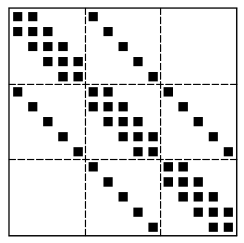

Here is the actual matrix for that same case:

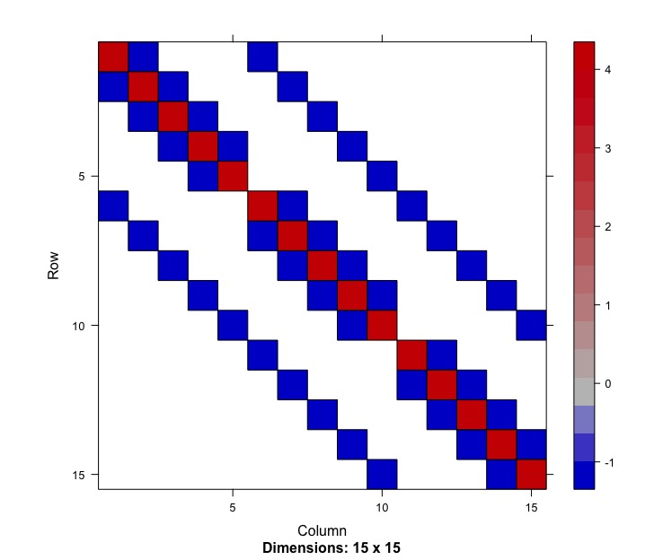

As a final example, here is the actual matrix for the case of $k_1=8$ and $k_2=4$

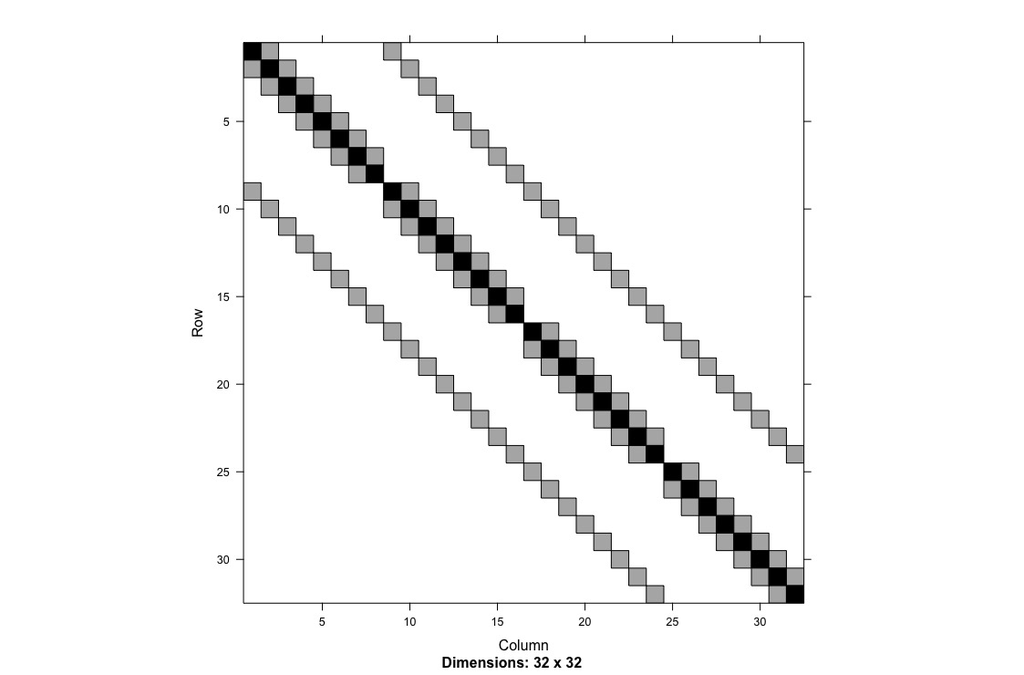

1. Generate the matrix $A$ above for the case of $k_1=5$ and $k_2=3$.

*Extra Credit*: Write a function `sparsePattern(k1,k2)` that takes any values of $k_1$ and $k_2$ and returns the matrix A. Check that it matches the examples above and try it on a couple of different matrices.

```r
B = function(start_i, k1) {
  return(list(
    i = c(start_i : (start_i+k1 -1) , start_i:(start_i+k1 -2), (start_i + 1):(start_i+k1 -1) ),
    j = c(start_i : (start_i + k1 -1),  (start_i + 1):(start_i+k1 -1), start_i:(start_i+k1 -2)  ),
    x = c(rep(4, k1), rep(-1, (k1-1)),rep(-1,(k1-1) ))
  ))
}


sparsePattern = function(k1,k2){
  n = k1*k2

  matrix = spMatrix(n, n,
                    i = c((k1 + 1):n    ,1:(n-k1) ),
                    j = c(1:(n-k1), (k1+1):n),
                    x = rep( rep(-1, (n-k1)), 2)
                    )
  for (start in seq(1, n, k1)) {
    b = B(start, k1)
    for (index in 1:(3*k1 -2) ){
      matrix[b$i[index], b$j[index]] = b$x[index]
    }
  }

  return(matrix)
}


(sparsePattern(5,3))
```

```
## 15 x 15 sparse Matrix of class "dgTMatrix"
##
##  [1,]  4 -1  .  .  . -1  .  .  .  .  .  .  .  .  .
##  [2,] -1  4 -1  .  .  . -1  .  .  .  .  .  .  .  .
##  [3,]  . -1  4 -1  .  .  . -1  .  .  .  .  .  .  .
##  [4,]  .  . -1  4 -1  .  .  . -1  .  .  .  .  .  .
##  [5,]  .  .  . -1  4  .  .  .  . -1  .  .  .  .  .
##  [6,] -1  .  .  .  .  4 -1  .  .  . -1  .  .  .  .
##  [7,]  . -1  .  .  . -1  4 -1  .  .  . -1  .  .  .
##  [8,]  .  . -1  .  .  . -1  4 -1  .  .  . -1  .  .
##  [9,]  .  .  . -1  .  .  . -1  4 -1  .  .  . -1  .
## [10,]  .  .  .  . -1  .  .  . -1  4  .  .  .  . -1
## [11,]  .  .  .  .  . -1  .  .  .  .  4 -1  .  .  .
## [12,]  .  .  .  .  .  . -1  .  .  . -1  4 -1  .  .
## [13,]  .  .  .  .  .  .  . -1  .  .  . -1  4 -1  .
## [14,]  .  .  .  .  .  .  .  . -1  .  .  . -1  4 -1
## [15,]  .  .  .  .  .  .  .  .  . -1  .  .  . -1  4
```

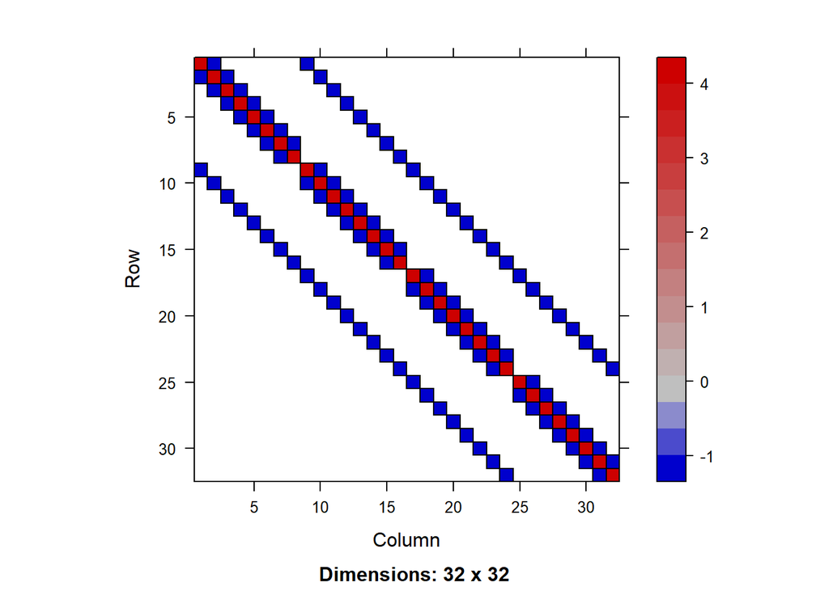

```r
options(max.print = .Machine$integer.max)

image(sparsePattern(8,4))
```

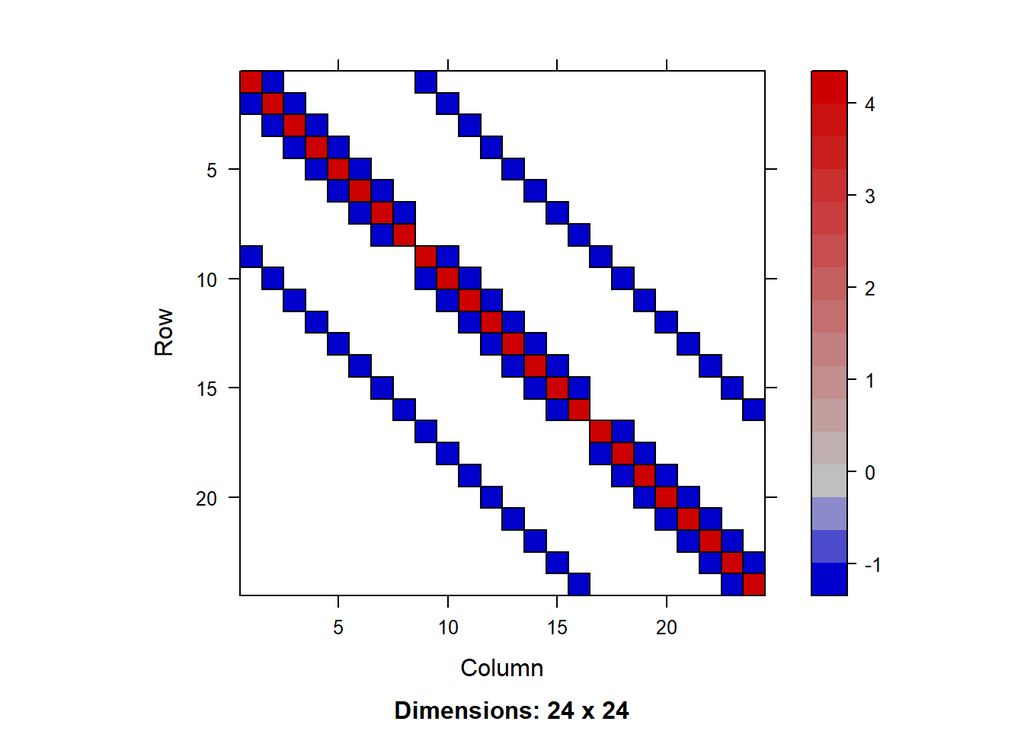

```r
image(sparsePattern(8,3))
```

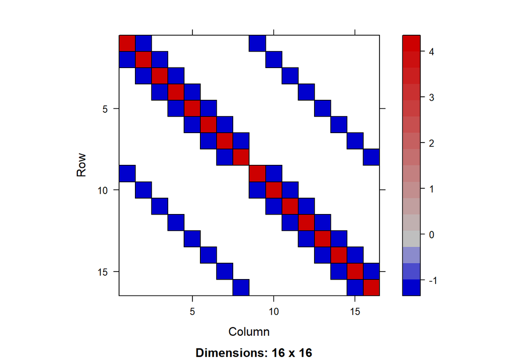

```r
image(sparsePattern(8,2))
```

2. One issue with using the LU decomposition on a sparse matrix like $A$ is that the factors $L$ and $U$ have more non-zero entries than $A$. This phenomenon is called *fill-in*. Here is an example you can try once you have formed $A$:

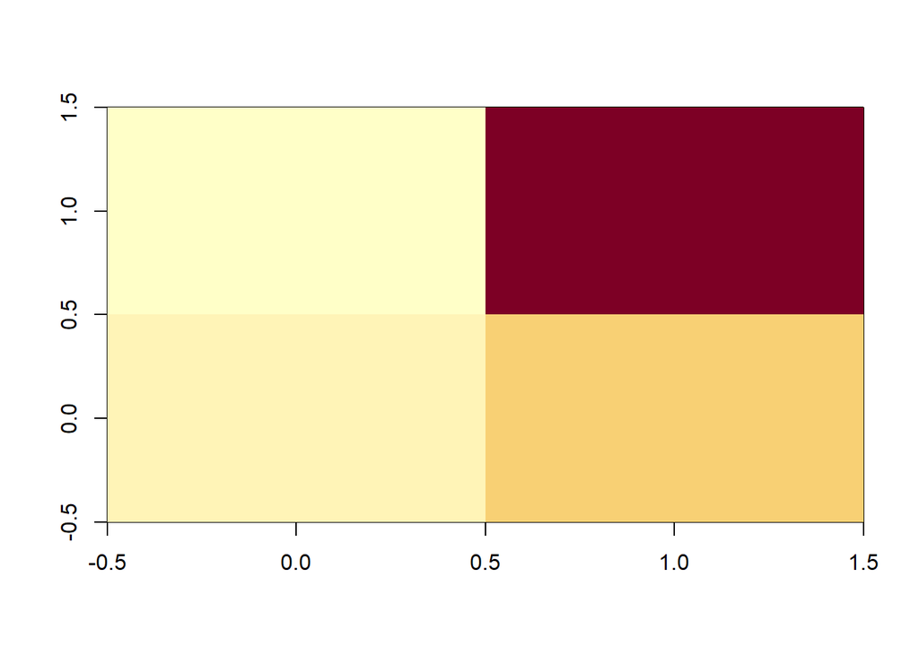

   ```r
   out <- myLUFast(as.matrix(A))
   L <- as(out$L,"sparseMatrix")
   U <- as(out$U,"sparseMatrix")
   image(A)
   ```

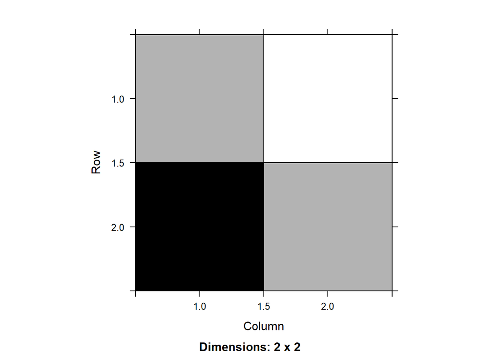

   ```r
   image(L)
   ```

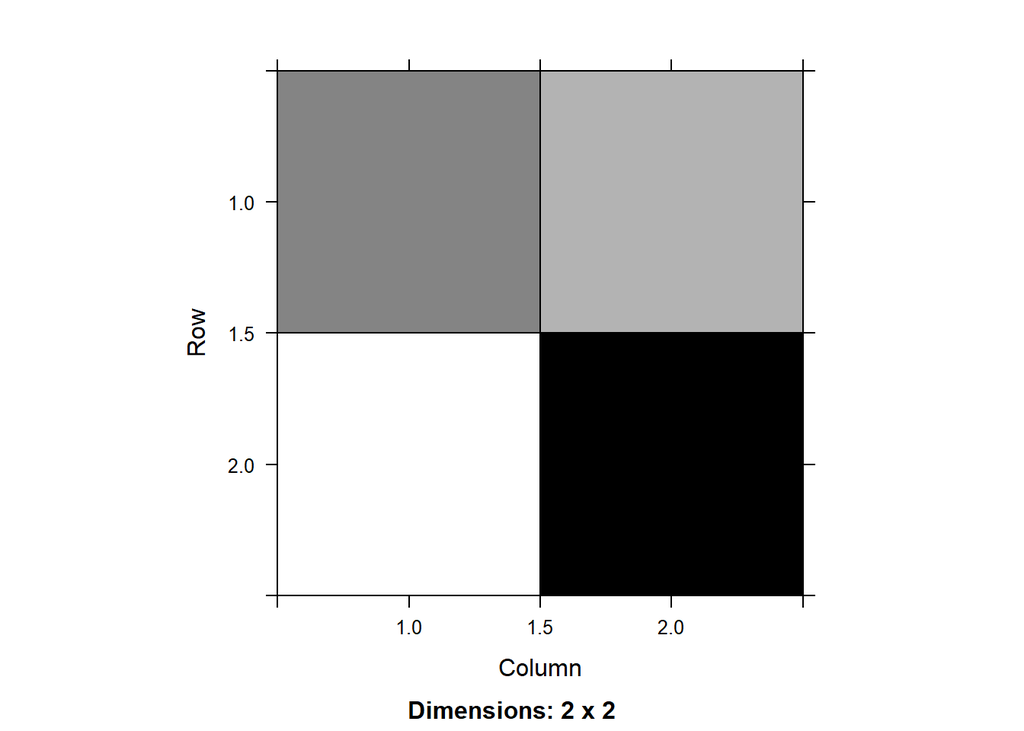

   ```r
   image(U)
   ```

Can we find triangular matrices $L$ and $U$ that are sparser and still satisfy $A=LU$? No, recall that the factorization is unique. Instead, one approach is to force $L$ and $U$ to be sparser, but have $LU$ only approximate $A$.

Your main task is to write a function `mySparseLU` that returns a lower unit triangular matrix $L$ and an upper triangular matrix $U$ such that $L$ and $U$ only have off-diagonal non-zeros entries in the locations where $A$ has off-diagonal non-zero entries. In the following pseudocode for the algorithm, $NZ(A)$ is the set of indices of non-zero entries of $A$. For example, if $A(3,4)\neq 0$, then $(3,4)\in NZ(A)$.

### Pseudocode for Sparse LU Approximate Factorization

Input: $A$

Output: $L$ (lower unit triangular) and $U$ (upper triangular)

1. **for** $i=2,3,\ldots,n$ **do**
2. $~~~$ **for** $k=1,2,\ldots,i-1$ and for $(i,k)\in NZ(A)$ **do**
3. $~~~~~~~~~~~A_{ik}={A_{ik}}~/~{A_{kk}}$
4. $~~~~~~~~~~~$**for** $j=k+1,\ldots,n$ and for $(i,j)\in NZ(A)$ **do**
5. $~~~~~~~~~~~~~~~~~A_{ij}=A_{ij}-A_{ik}A_{kj}$
6. $~~~~~~~~~~~$**end for**
7. $~~~$ **end for**
8. **end for**
9. Let $U$ be the upper triangular part of $A$ (including the diagonal)
10. Let $L$ be the strictly lower triangular part of $A$ (not including the diagonal)
11. Set every element of the diagonal of $L$ to be 1

Your function `mySparseLU(A)` should return a list containing $L$ and $U$.

Test it by activating the following code:

```
out <- mySparseLU(A)
image(out$L)
image(out$U)
```

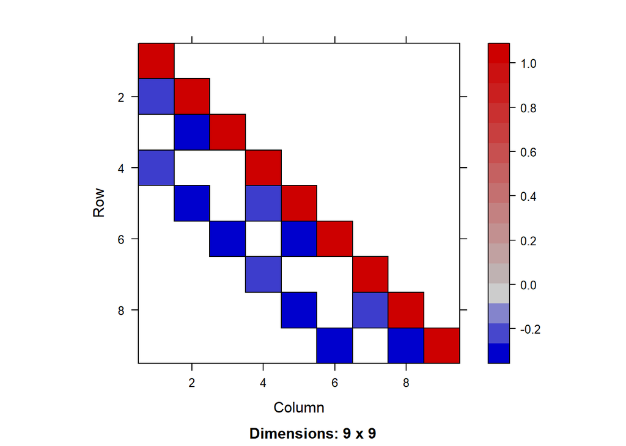

```r
mySparseLU = function(A){

  n <- nrow(A)
  for(i in 2:n){
    for(k in 1:(i-1)){
      if(A[i,k] != 0){
        A[i,k] = A[i,k]/A[k,k]
        for(j in (k+1)){
          if(A[i,j] != 0){
            A[i,j] = A[i,j] - A[i,k]*A[k,j]
          }
        }
      }
    }
  }
  U = triu(A)
  L = tril(A, -1)
  for(i in 1:n){
    L[i,i] = 1
  }


  return(list(L=L,U=U))
}


A = sparsePattern(3,3)

out <- mySparseLU(A)
image(out$L)
```

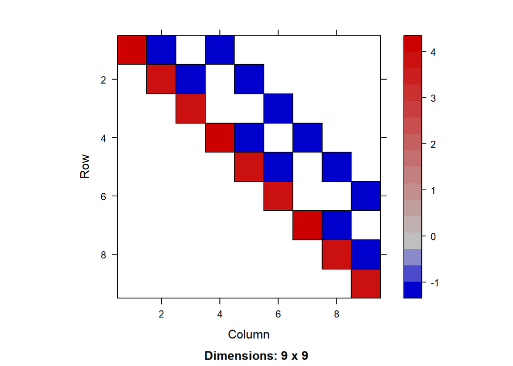

```r
image(out$U)
```